# PSTAT 131 Final Project

Lila He (Chenhui He), Hanzhi Zhang, Amy Gu

2022/3/2

# Introduction

[figure not shown]

```r
knitr::include_graphics("League of Legends.png")
```

League of Legends is a popular Multiplayer online battle arena (MOBA) game in the world. It is about to be listed as one of the events in The 19th Asian Games Hangzhou 2022. This dataset is from Riot Gaming in Diamond I to the Master Rank Game of League of Legends. In order to see what decisions in the first ten minutes will lead a team to win the game, we are trying to fit a model to predict how various factors will affect the result of a ranked game. We may use Logistic Regression, K nearest neighbor, bagging, randomForest, and boosted tree to analyze this dataset.

## What is League of legends?

League of Legends is a team-based strategy game where two teams of five powerful champions face off to destroy the other’s base. Choose from over 140 champions to make epic plays, secure kills, and take down towers as you battle your way to victory.

**Goal: Destroy The Base**

The Nexus is the heart of both teams’ bases. Destroy the enemy’s Nexus first to win the game.

**Structures: Clear the Path**

Your team needs to clear at least one lane to get to the enemy Nexus. Blocking your path are defense structures called turrets and inhibitors. Each lane has three turrets and one inhibitor, and each Nexus is guarded by two turrets.

**Neutral Monsters: Take On The Jungle**

In between the lanes is the jungle, where neutral monsters and jungle plants reside. The two most important monsters are Baron Nashor and the Drakes. Killing these units grants unique buffs for your team and can also turn the tide of the game.

**Lane Positions: Choose Your Lane**

There are five positions that make up the recommended team comp for the game. Each lane lends itself to certain kinds of champions and roles—try them all or lock in to the lane that calls you.

**Powering Up: Power Up Your Champ**

Champions get stronger by earning experience to level up and gold to buy more powerful items as the game progresses. Staying on top of these two factors is crucial to overpowering the enemy team and destroying their base.

**Abilities, Spells & Items: Unlock Your Abilities**

Champions have five core abilities, two special spells, and up to seven items at a time. Figuring out the optimal ability order, summoner spells, and item build for your champion will help you succeed as a team.

From League of Legends Official Website: [https://www.leagueoflegends.com/en-us/how-to-play/]

For detailed introduction, please watch this short video:

```r
library(vembedr)
embed_youtube("BGtROJeMPeE")
```

[video not shown]

## Goal of this study

Since players will meet different enemies and teammates in diamond rank, the situation of the game may be different from the lower rank games. The goal of this study is to help the players in diamond rank games to learn about which decisions in the first ten minutes have an impact on winning a ranked game from this model.

## Loading Data and Packages

**Loading Data**

Since we are interested in the video game League of Legends, we searched on the website Kaggle. By sorting through the usability, we finally choose this dataset. [https://www.kaggle.com/bobbyscience/league-of-legends-diamond-ranked-games-10-min]

```r
# read in the data
RankData <- read.csv("high_diamond_ranked_10min.csv")
```

**Check the dimension**

```r
dimension <- dim(RankData)
dimension
```

```
## [1] 9879   40
```

This dataset includes 40 columns and 9879 observations. There are 1 response variable and 38 predictor variables. And 36 of them are numeric and 2 of them are binary. The response variable is the ‘blueWins’. It is the result whether the blue side wins (“1” stands for blue wins and “0” stands for red wins). The description of explanation for predictor variables are in our codebook document.

**Loading Packages**

We loaded fallowing packages: tidyverse, ForImp, dplyr, randomForest, gbm, ISLR, tree, class, corrplot, ROCR, readr, caret, factoextra

# Data Cleaning

**Exclude gameID column**

One of the variables is the “gameID”. Since the “gameID” is just a kind of identity and it won’t influence the result of each rank game, we excluded the “gameID” column.

```r
RData <- RankData %>%
  select(-gameId)
```

Then, we move blueWins to the first column.

```r
blueWins = RData[,1]
```

**Select important variables**

For the variables end with “PerMin” come from total variables like blueGoldPerMin, it is from the blueTotalGold. At the same time, variable blueKills is equal to the redDeaths. The variables “redGoldDiff” and “redExperienceDiff” come from blueTotalGold minus blueGoldDiff, blueTotalExperience minus blueExperienceDiff. Since “FirstBlood” variable is a binary variable, it will be done by red team or blue team, we only keep one.

We exclude the following variables: blueCSPerMin, redCSPerMin, blueGoldPerMin, redGoldPerMin, redDeaths, redFirstBlood, blueDeaths, redGoldDiff, redExperienceDiff

```r
blueData = RData %>%
  select(-blueCSPerMin, -redCSPerMin, -blueGoldPerMin, -redGoldPerMin, -redDeaths, -redFirstBlood, -blueDeaths, -redGoldDiff, -redExperienceDiff)
```

**Check missing value**

```r
sum(is.na(blueData))
```

```
## [1] 0
```

After checking, we see that there is no missing value in our dataset now. We finished our data cleaning process.

# Exploratory Data Analysis

## Summary the data

In order to get more descriptive characters of the data set, we summary the data.

From the summary, we can see that the mean of blueWins is 0.499, therefore we can assume the game is fair.

We also find some funny numbers that the Max for redTowersDestroyed is 2 and Max for blueTowersDestroyed is 4. If TowersDestroyed is doubled for blue team, there must be something else that help red team to make up for its lack of destroyed tower or TowersDestroyed is not highly correlated with the result of wins.

```r
summary(blueData)
```

```
##     blueWins     blueWardsPlaced  blueWardsDestroyed blueFirstBlood
##  Min.   :0.000   Min.   :  5.00   Min.   : 0.000     Min.   :0.0000
##  1st Qu.:0.000   1st Qu.: 14.00   1st Qu.: 1.000     1st Qu.:0.0000
##  Median :0.000   Median : 16.00   Median : 3.000     Median :1.0000
##  Mean   :0.499   Mean   : 22.29   Mean   : 2.825     Mean   :0.5048
##  3rd Qu.:1.000   3rd Qu.: 20.00   3rd Qu.: 4.000     3rd Qu.:1.0000
##  Max.   :1.000   Max.   :250.00   Max.   :27.000     Max.   :1.0000
##    blueKills       blueAssists     blueEliteMonsters  blueDragons
##  Min.   : 0.000   Min.   : 0.000   Min.   :0.00      Min.   :0.000
##  1st Qu.: 4.000   1st Qu.: 4.000   1st Qu.:0.00      1st Qu.:0.000
##  Median : 6.000   Median : 6.000   Median :0.00      Median :0.000
##  Mean   : 6.184   Mean   : 6.645   Mean   :0.55      Mean   :0.362
##  3rd Qu.: 8.000   3rd Qu.: 9.000   3rd Qu.:1.00      3rd Qu.:1.000
##  Max.   :22.000   Max.   :29.000   Max.   :2.00      Max.   :1.000
##   blueHeralds    blueTowersDestroyed blueTotalGold    blueAvgLevel
##  Min.   :0.000   Min.   :0.00000     Min.   :10730   Min.   :4.600
##  1st Qu.:0.000   1st Qu.:0.00000     1st Qu.:15416   1st Qu.:6.800
##  Median :0.000   Median :0.00000     Median :16398   Median :7.000
##  Mean   :0.188   Mean   :0.05142     Mean   :16503   Mean   :6.916
##  3rd Qu.:0.000   3rd Qu.:0.00000     3rd Qu.:17459   3rd Qu.:7.200
##  Max.   :1.000   Max.   :4.00000     Max.   :23701   Max.   :8.000
##  blueTotalExperience blueTotalMinionsKilled blueTotalJungleMinionsKilled
##  Min.   :10098       Min.   : 90.0          Min.   : 0.00
##  1st Qu.:17168       1st Qu.:202.0          1st Qu.:44.00
##  Median :17951       Median :218.0          Median :50.00
##  Mean   :17928       Mean   :216.7          Mean   :50.51
##  3rd Qu.:18724       3rd Qu.:232.0          3rd Qu.:56.00
##  Max.   :22224       Max.   :283.0          Max.   :92.00
##   blueGoldDiff       blueExperienceDiff redWardsPlaced   redWardsDestroyed
##  Min.   :-10830.00   Min.   :-9333.00   Min.   :  6.00   Min.   : 0.000
##  1st Qu.: -1585.50   1st Qu.:-1290.50   1st Qu.: 14.00   1st Qu.: 1.000
##  Median :    14.00   Median :  -28.00   Median : 16.00   Median : 2.000
##  Mean   :    14.41   Mean   :  -33.62   Mean   : 22.37   Mean   : 2.723
##  3rd Qu.:  1596.00   3rd Qu.: 1212.00   3rd Qu.: 20.00   3rd Qu.: 4.000
##  Max.   : 11467.00   Max.   : 8348.00   Max.   :276.00   Max.   :24.000
##     redKills        redAssists     redEliteMonsters   redDragons
##  Min.   : 0.000   Min.   : 0.000   Min.   :0.0000   Min.   :0.0000
##  1st Qu.: 4.000   1st Qu.: 4.000   1st Qu.:0.0000   1st Qu.:0.0000
##  Median : 6.000   Median : 6.000   Median :0.0000   Median :0.0000
##  Mean   : 6.138   Mean   : 6.662   Mean   :0.5731   Mean   :0.4131
##  3rd Qu.: 8.000   3rd Qu.: 9.000   3rd Qu.:1.0000   3rd Qu.:1.0000
##  Max.   :22.000   Max.   :28.000   Max.   :2.0000   Max.   :1.0000
##    redHeralds   redTowersDestroyed  redTotalGold    redAvgLevel
##  Min.   :0.00   Min.   :0.00000    Min.   :11212   Min.   :4.800
##  1st Qu.:0.00   1st Qu.:0.00000    1st Qu.:15428   1st Qu.:6.800
##  Median :0.00   Median :0.00000    Median :16378   Median :7.000
##  Mean   :0.16   Mean   :0.04302    Mean   :16489   Mean   :6.925
##  3rd Qu.:0.00   3rd Qu.:0.00000    3rd Qu.:17419   3rd Qu.:7.200
##  Max.   :1.00   Max.   :2.00000    Max.   :22732   Max.   :8.200
##  redTotalExperience redTotalMinionsKilled redTotalJungleMinionsKilled
##  Min.   :10465      Min.   :107.0         Min.   : 4.00
##  1st Qu.:17210      1st Qu.:203.0         1st Qu.:44.00
##  Median :17974      Median :218.0         Median :51.00
##  Mean   :17962      Mean   :217.3         Mean   :51.31
##  3rd Qu.:18765      3rd Qu.:233.0         3rd Qu.:57.00
##  Max.   :22269      Max.   :289.0         Max.   :92.00
```

## Win Rate When Has a Gold Advantage

Based on the observations of summary, we found that Gold Difference has large impact on the win rate of both teams. We decided to make a graph to show the win rate if a team has gained a gold advantage during first 10 mins of a rank game. In the plot, we could see that blue team had about 70% win rate when get gold advantage, which is a positive gold difference. The red team also had about 70% win rate when get gold advantage. So, both teams has the same win rate when get gold advantage.

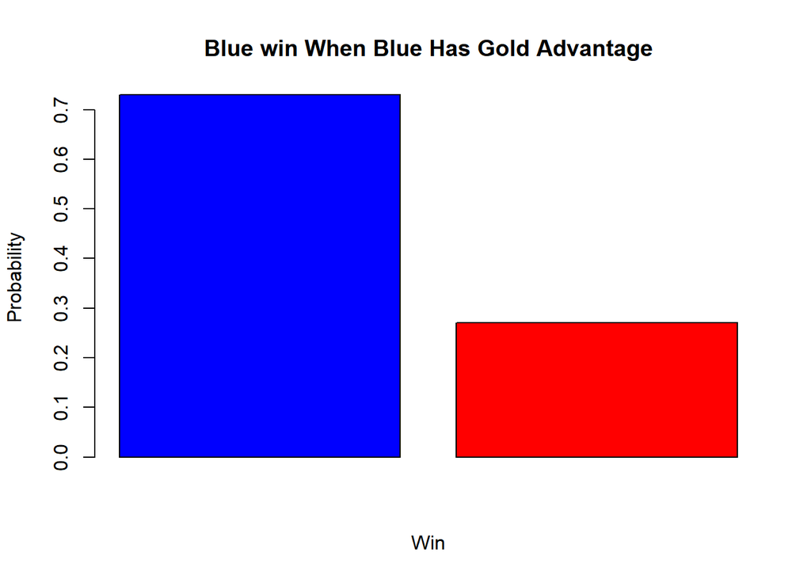

```r
red_wins <- nrow(blueData[blueData$blueWins == "0",])
blue_wins <- nrow(blueData[blueData$blueWins == "1",])
blue_wins_ga <- filter(blueData, blueGoldDiff > 0 & blueWins == "1")
blue_wins_gd <- filter(blueData, blueGoldDiff < 0 & blueWins == "1")
red_wins_ga <- filter(blueData, blueGoldDiff > 0 & blueWins == "0")
red_wins_gd <- filter(blueData, blueGoldDiff < 0 & blueWins == "0")
prob_blue_wins_ga <- round((length(blue_wins_ga[,1]))/blue_wins, digits = 2)
prob_blue_wins_gd <- round((length(blue_wins_gd[,1]))/blue_wins, digits = 2)
prob_red_wins_ga <- round((length(red_wins_ga[,1]))/red_wins, digits = 2)
prob_red_wins_gd <- round((length(red_wins_gd[,1]))/red_wins, digits = 2)
prob_blue_wins_gold <- c(prob_blue_wins_ga, prob_blue_wins_gd)
prob_red_wins_gold <- c(prob_red_wins_ga, prob_red_wins_gd)
barplot(prob_blue_wins_gold, main = "Blue win When Blue Has Gold Advantage",
        xlab = "Win", ylab = "Probability",
        col = c("blue", "red"))
```

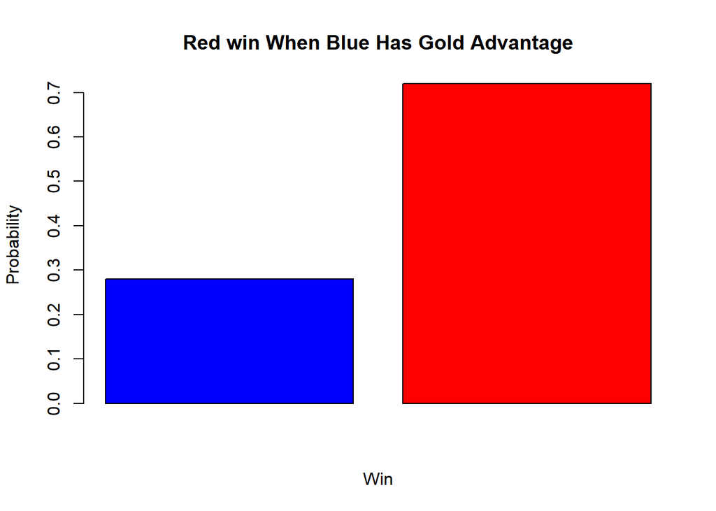

```r
barplot(prob_red_wins_gold, main = "Red win When Blue Has Gold Advantage",
        xlab = "Win", ylab = "Probability",
        col = c("blue", "red"))
```

## Fairness

In order to make sure that the game is fair for two teams, we compared the probability to win this ranked game of each team.

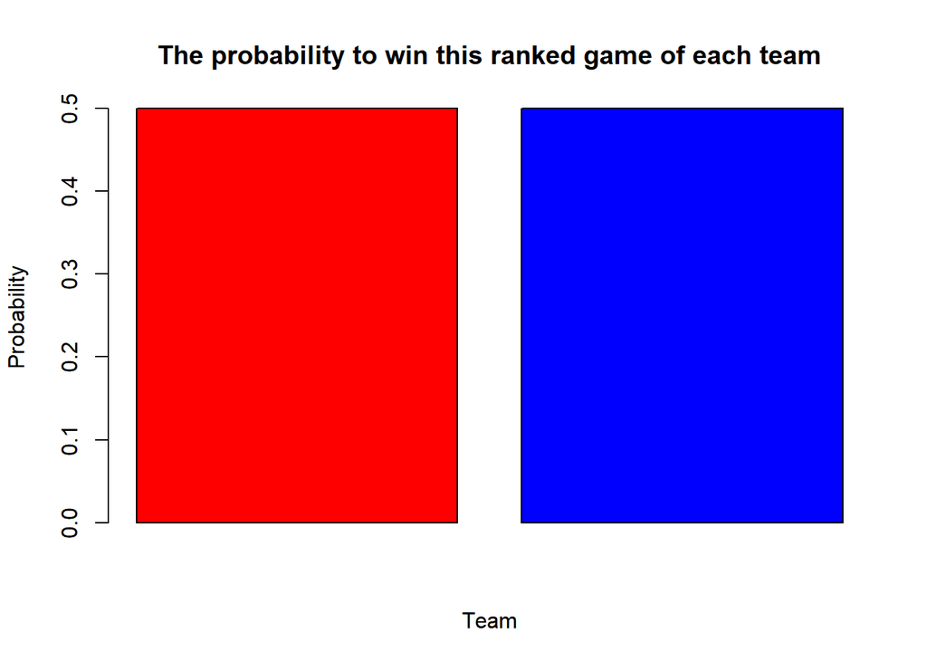

```r
red_wins <- nrow(blueData[blueData$blueWins == "0",])
blue_wins <- nrow(blueData[blueData$blueWins == "1",])
prob_red_wins <- round((nrow(blueData[blueData$blueWins == "0",])) / length(blueData[,1]), digits = 2)
prob_blue_wins <-  round((nrow(blueData[blueData$blueWins == "1",])) / length(blueData[,1]), digits = 2)
prob_wins <- c(prob_red_wins, prob_blue_wins)
barplot(prob_wins, main = "The probability to win this ranked game of each team",
        xlab = "Team", ylab = "Probability",
        col = c("red", "blue"))
```

After checking the probability, we found that both teams have 50% probability to win the game. So the game is fair.

## Correlation 1

By using a heat map to represent the correlation matrix between the variables, we can better understand the structure of the dataset. We don’t want two variables which are highly correlated exist at the same time because that’s meaningless.

The color blue indicates whether the variables are positively correlated, the color red indicates the variables are negatively correlated, and white indicates that they are not correlated.

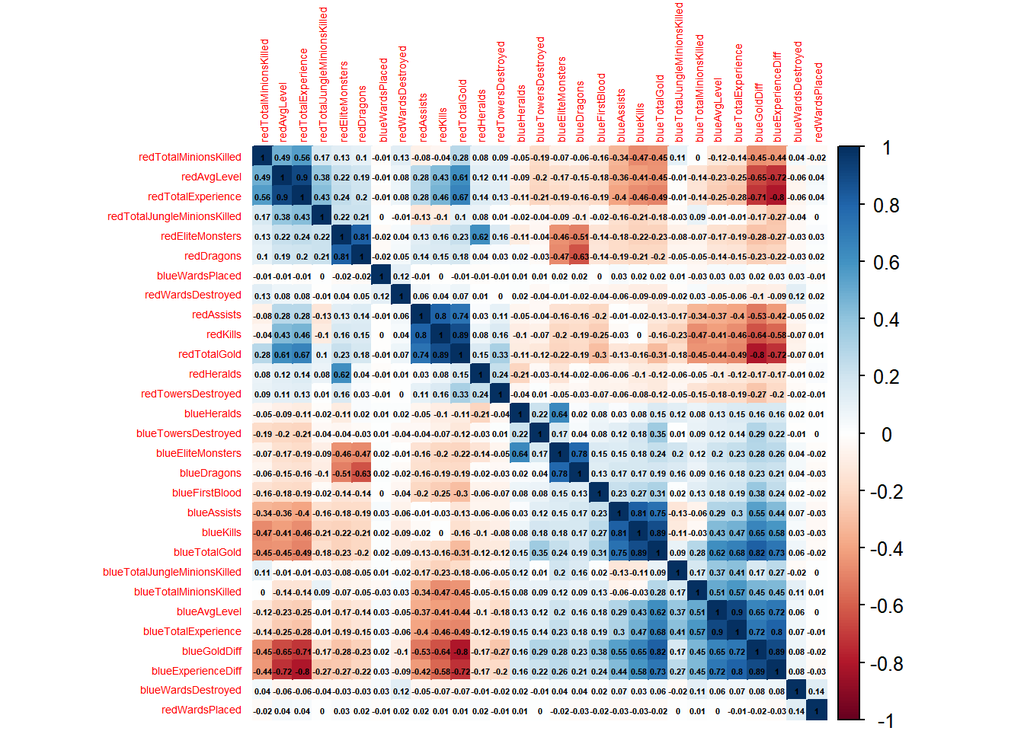

```r
CorrMatrix<-cor(blueData%>%select(-1))
corrplot(CorrMatrix,method = "color",type = "full", addCoef.col = "black", order = "hclust", tl.cex = 0.45,number.cex = 0.35)
```

First, we want to introduce this heat map. From this graph,there are 2 key discoverys:

First, The variables associated with the red team are negatively correlated with the variables associated with the blue team.For example,redTotalGold is negatively correlated with blueExperienceDiff and blueGoldDiff.

Second, the darker the colors are, the more correlations between these variables. We found some variables are more correlated with some variables than any other. For example, blueGoldDiff and blueExperienceDiff are more negatively correlated with redAvgLevel and redTotalExperience.

We have the variables associated with the red team like redKills, redAssists, redTotalGold etc. We have the variables associated with the blue team like blueKills, blueAssists, blueTotalGold etc. Also, we have the variables that are not really correlated with anything, like redWardsPlaced, redWardDestroyed, etc.

## PCA

When we have too many variables, we need to use PCA to reach dimensionality reduction of the data and compress the variables into fewer sets

**PVE Value**

```r
pr.out = prcomp(blueData%>%select(-1), scale = TRUE)
pve = pr.out$sdev^2 / sum(pr.out$sdev^2)
pve
```

```
##  [1] 2.762793e-01 9.918036e-02 8.763221e-02 6.603304e-02 4.896869e-02
##  [6] 4.692543e-02 4.293890e-02 4.103728e-02 3.691921e-02 3.204154e-02
## [11] 3.042790e-02 2.949028e-02 2.852803e-02 2.656788e-02 2.457817e-02
## [16] 2.270625e-02 1.547675e-02 1.293552e-02 1.082043e-02 6.543684e-03
## [21] 5.335598e-03 3.307898e-03 2.690075e-03 1.558808e-03 1.076749e-03
## [26] 4.355957e-31 2.853827e-31 1.928274e-31 1.571341e-31
```

**PVE and Cumulative PVE Plot**

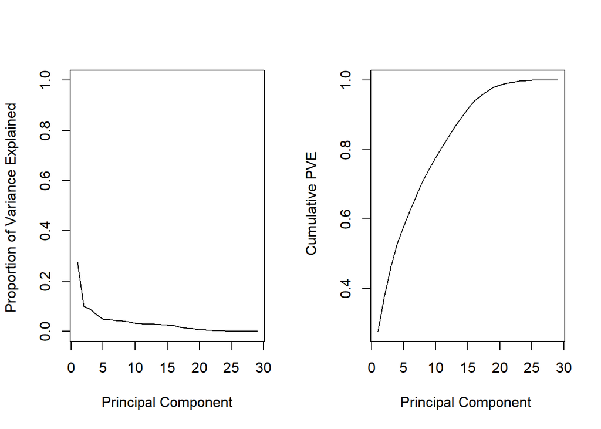

```r
par(mfrow = c(1,2))
plot(pve,xlab="Principal Component",
     ylab="Proportion of Variance Explained ", ylim=c(0,1),type='l')
plot(cumsum(pve), xlab="Principal Component ",
     ylab=" Cumulative PVE", type = "l")
```

**PCA Plot**

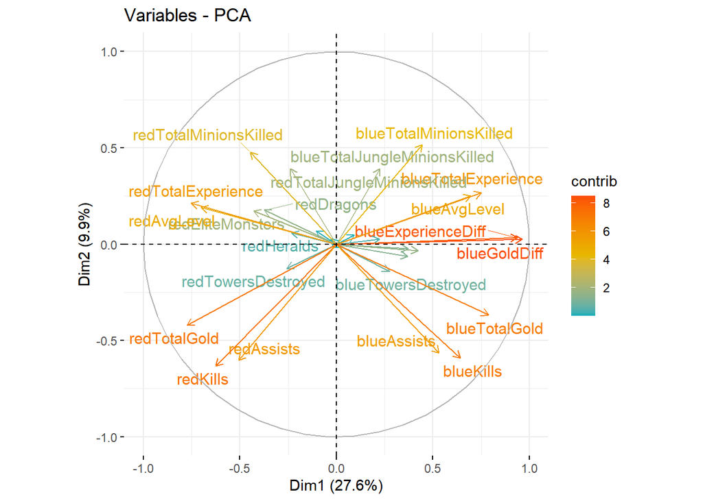

```r
fviz_pca_var(pr.out,
             col.var = "contrib",
             gradient.cols = c("#00AFBB", "#E7B800", "#FC4E07"),
             repel = TRUE)
```

## Corrlation 2

Because we focus on the factors that will lead a team to win in the first 10 minutes, it’s a binary question and in order to investigate more in-depth the link between the variables, We only consider the variables related with the blue team (such as blueKills, blueTotalGold, etc.). We also remove the variables which are highly correlated.

For instance, blueEliteMonsters is highly correlated with blueDragons.(Since the refresh time of elite monsters is eariler than dragons, players can gain more gold and experience from killing elite monsters, which help them to have higher attack when killing the dragon.)

Also, blueAvgLevel is highly correlated with blueTotalExperience, (it’s easy to understand, right? When you practice more, which means you have more experience, usually you can reach a higher level of what you have practiced. We all know, practice makes perfection).

So we choose one of them from blueEliteMonsters and blueDragons. At the same time, we choose one of them from blueTotalExperience and blueAvgLevel. Then we plot correlation matrix using a heatmap to visualize the data.

```r
BData = blueData %>% select(blueWins:blueExperienceDiff)
BData = BData %>% select(-blueEliteMonsters, -blueAvgLevel)
```

From the heat map, we can see that blueGoldDiff is highly positive correlated with blueTotalExperience, blueExperienceDiff, and blueTotalGold. In addition, blueTotalGold is highly positive correlated with blueAssists and blueKills.

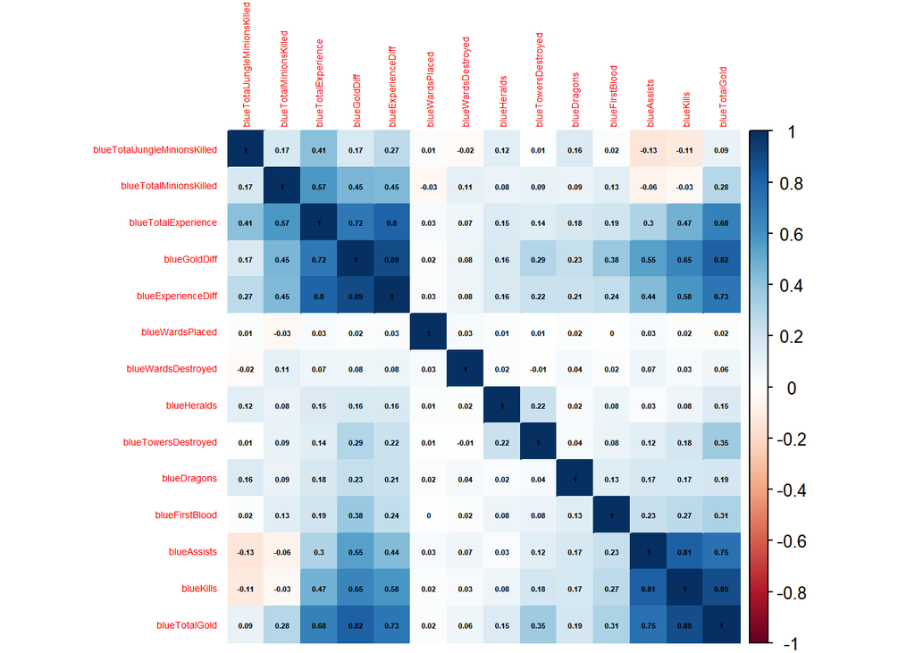

```r
CorrMatrix2<-cor(BData%>%select(-1))
corrplot(CorrMatrix2,method = "color",type = "full", addCoef.col = "black", order = "hclust", tl.cex = 0.45,number.cex = 0.35)
```

# Data Splitting

Because we only have one data set, when we finish model building, we want to estimate the generalization performance, so we do data splitting. If we use the same data when we train the model and estimate its performance, then we will get a much more optimistic result when we estimate, there will be a lack of accuracy. And we checked the dimension of them.

```r
set.seed(1)

#We take 80% training data and 20% testing data.
train <- sample(1:nrow(BData), 0.8*nrow(BData))

blueData.train <- BData[train,]
blueData.test <- BData[-train,]

# dimensions of training dataset
dim(blueData.train)
```

```
## [1] 7903   15
```

```r
# dimensions of test dataset
dim(blueData.test)
```

```
## [1] 1976   15
```

We take 80% training data and 20% testing data.

There are 7903 observations in the training dataset. There are 1976 observations in the test dataset.